# Demo-Data analysis

Li-Pang Chen and Bangxu Qiu

2023-06-16

## R Markdown

In this R Markdown, we demonstrate analysis of the Signal Tandmobiel Study in the main text entitled “Analysis of Length-Biased and Partly Interval-Censored Survival Data with Mismeasured Covariates”. To illustrate our analysis, we primarily focus on tooth label 11 as shown in the main text. If one would like to examine other teeth as demonstrated in the supporting information, then the command in “tandmob2” can be adjusted manually.

In the following code, we aim to reproduce the result and separately examine several estimation methods in the main text. All methods’ names can be referred to the main text. To simply the illustration and focus on showing different methods, we fix the misclassification probability 0.05 when correcting for measurement error (Methods 1 and 5); one can revise the code manually to demonstrate 0.005 misclassification probability.

Method 1: SIMEXboost(0.05)

```r
#upload a dataset from .RData
load("C:\\Users\\user\\Downloads\\tandmob2.RData") #tandmob2 is a dataset

#required packages
library(mice)
library(DMwR2)
library(openxlsx)
library(survival)
library(survminer)
#Data setup

## Note: From the datasets, responses for tooth label 11 are columns 21 and 22. Following an order in the main text, labels are 21, 31, 41, and so on, and the corresponding columns are (20,21),(22,23),(24,25), and so on.

## keep tooth label 11 from columns 21 and 22 and remove NA to get interval-censored responses
AA<-tandmob2[-c(which(is.na(tandmob2[,21]))),]
A<-AA[-c(which(is.na(AA[,22]))),]

## remove the first three non-informative columns and other teeth labels
data<-A[,c(-1,-2,-4,-(23:32),-(33:132))]
C<-mice(data,m=3,method = "pmm",maxit = 10,seed=163)
data1<-complete(C)
data1<-data1[-c(1741:(length(A[,1]))),]
Y<-cbind(data1[,18],data1[,19])
data2<-data1[,c(-(18:19))]


dataF<-centralImputation(cbind(Y,data2))

TtutaSet<-NULL;dataF1=dataF;

## 5-fold cross validation
for(kfold in 1:5){
  n=length(dataF1[,1]);p=41;betazero=t(rep(0,p));namita=0.03
  dataF2=dataF1[-c((((kfold-1)*(n/5))+1):(((kfold)*(n/5)))),]

  LR<-cbind(dataF2[,1],dataF2[,2])

  betarbind<-NULL;eta<-c(0,0.25,0.5,0.75,1);B=5
  for(cc in 1:length(eta)){
    betaihat<-NULL
    for(i in 1:B){
      X1<-t(dataF2[,c(3:43)])
      Xchange1<-X1[c(1,(5:41)),]
      orthogonal<-matrix(c(sqrt(0.5),sqrt(0.5),sqrt(0.5),-sqrt(0.5)),nrow=2,ncol=2,byrow=TRUE)
      orthogonalT<-t(orthogonal)
      piepsilon<-orthogonalT%*%(diag(c(1^(eta[cc]),0.9^(eta[cc]))))%*%orthogonal
      # 0.9 here is for misclassification probability 0.05; 0.99 can be used to   represent misclassification probability 0.005. It is due to the decomposition of a matrix. See the main text for details.
      Xchange1pSet<-NULL
      for(s in 1:length(Xchange1[,1])){
        exchange1<-runif(length(X1[1,]),0,1)
        change1=which(exchange1<piepsilon[2])
        Xchange1p<-Xchange1[s,]
        if(length(change1)!=0) for(o in 1:length(change1)){
          if(Xchange1[s,][change1[o]]==(0)) Xchange1p[change1[o]]=1
          else Xchange1p[change1[o]]=(0)
        }
        Xchange1pSet<-rbind(Xchange1pSet,Xchange1p)
      }

      Wetab<-rbind(Xchange1pSet[1,],X1[c(2:4),],Xchange1pSet[c(2:38),])

      X1censor<-Wetab
      TT1censor<-log(LR[,1]);TT1<-TT1censor
      functionx<-function(x){
        b=1/(exp(1)*(exp(1)-1))
        a=(log(x)/x)*(b/((pi)*(((log(x)/x)^2)+b^2)))
        return(a)
      }
      function2<-function(x){
        b=1/(exp(1)*(exp(1)-1))
        a=(b/((pi)*(((log(x)/x)^2)+b^2)))
        return(a)
      }
      Iter=50;time=0
      for(j in 1:Iter){
        betazero1=betazero
        Lbeta1<-NULL
        for(i in 1:length(TT1censor)){
          Lbeta<-(LR[,1][i]*exp(-sum(X1censor[,i]*betazero1)))
          Lbeta1<-cbind(Lbeta1,Lbeta)
        }
        Rbeta1<-NULL
        for(i in 1:length(TT1censor)){
          Rbeta<-(LR[,2][i]*exp(-sum(X1censor[,i]*betazero1)))
          Rbeta1<-cbind(Rbeta1,Rbeta)
        }
        dFtgeneration<-NULL
        for(i in 1:length(TT1censor)){
          a<-runif(1000,Lbeta1[i],Rbeta1[i])
          a1<-functionx(a)
          dFt=sum((Rbeta1[i]-Lbeta1[i])*a1)/length(a1)
          b<-runif(1000,Lbeta1[i],Rbeta1[i])
          b1<-function2(b)
          dFt1<-sum((Rbeta1[i]-Lbeta1[i])*b1)/length(b1)
          censorYi<-dFt/dFt1
          dFtgeneration<-rbind(dFtgeneration,censorYi)
        }
        for(i in 1:length(dFtgeneration)){
          if(dFtgeneration[i]=="Inf") dFtgeneration[i]=0
          if(dFtgeneration[i]=="-Inf") dFtgeneration[i]=0
          if(dFtgeneration[i]=="NaN") dFtgeneration[i]=0
        }
        ubetastep2<-NULL
        for(i in 1:length(dFtgeneration)){
          a<-X1censor[,i]*dFtgeneration[i]-namita*betazero1
          ubetastep2<-rbind(ubetastep2,a)
        }
        #compute u
        ubetastep<-ubetastep2
        u<-NULL
        for(i in 1:p){
          u<-c(u,sum(ubetastep[,i])/length(TT1))
        }
        for(i in 1:p){
          Delta=u
          #if(abs(Delta[i])>0.6*max(abs(Delta))) betazero[i]=betazero[i]+0.01*sign(Delta[i])#Delta[i]=Delta[i]+0.05*sign(Delta[i])
          if(abs(Delta[i])>0*max(abs(Delta))) betazero[i]=betazero[i]+0.02*sign(Delta[i])
          #if(abs(Delta[i])==max(abs(Delta))) betazero[i]=betazero[i]+0.005*Delta[i]
          #if(time==Iter/2) betazero[which(abs(betazero)<0.05)]=0
          if(time==Iter-1) betazero[which(abs(betazero)<0.02)]=0
        }
        time=time+1
      }
      betaihat<-rbind(betaihat,betazero)
    }
    betarbind<-rbind(betarbind,betaihat)
  }
  meanbeta0hat<-NULL;meanbeta0.25hat<-NULL;meanbeta0.5hat<-NULL;meanbeta0.75hat<-NULL;meanbeta1hat<-NULL
  beta0hat<-betarbind[1:B,];beta0.25hat<-betarbind[(B+1):(2*B),];
  beta0.5hat<-betarbind[((2*B)+1):(3*B),];beta0.75hat<-betarbind[((3*B)+1):(4*B),];
  beta1hat<-betarbind[((4*B)+1):(5*B),]
  for (i in 1:p){
    a<-mean(beta0hat[,i])
    b<-mean(beta0.25hat[,i])
    c<-mean(beta0.5hat[,i])
    d<-mean(beta0.75hat[,i])
    e<-mean(beta1hat[,i])
    meanbeta0hat<-cbind(meanbeta0hat,a)
    meanbeta0.25hat<-cbind(meanbeta0.25hat,b)
    meanbeta0.5hat<-cbind(meanbeta0.5hat,c)
    meanbeta0.75hat<-cbind(meanbeta0.75hat,d)
    meanbeta1hat<-cbind(meanbeta1hat,e)
  }


  gamma1hat<-NULL;gamma0hat<-NULL;
  for(i in 1:p){
    x<-c(0,0.25,0.5,0.75,1)
    y<-c(meanbeta0hat[i],meanbeta0.25hat[i],
         meanbeta0.5hat[i],meanbeta0.75hat[i],meanbeta1hat[i])
    c<-lm(y~x)

    gamma0<-as.numeric(c$coefficients[1])
    gamma1<-as.numeric(c$coefficients[2])


    gamma0hat<-c(gamma0hat,gamma0)
    gamma1hat<-c(gamma1hat,gamma1)

  }
  betacorrect<-gamma0hat-gamma1hat

  for(i in 1:p){
    if(abs(betacorrect[i])<0.005) betacorrect[i]=0
  }
  kfoldprec<-dataF1[c((((kfold-1)*(n/5))+1):((kfold*(n/5)))),][3:41]
  for(kk in 1:length(kfoldprec[,1])){
    Ttuta<-sum(kfoldprec[kk,]*betacorrect)
    TtutaSet<-c(TtutaSet,Ttuta)
  }

}
TT<-data.frame(exp(TtutaSet))

Set<-NULL
for(i in 1:length(TT[,1])){
  if(Y[i,1]<TT[i,]&Y[i,2]>TT[i,]) Set=c(Set,TT[i,])

}
interval<-which(Y[,1]<TT&Y[,2]>TT)

pin<-length(which(Y[,1]<TT&Y[,2]>TT))/length(Y[,1])
TtutaSet1<-TtutaSet[-interval]
Y1<-Y[-interval,]
doutSet<-NULL
for(i in 1:length(TtutaSet1)){
  dout<-min(abs(Y1[i,1]-exp(TtutaSet1[i]))/(Y1[i,1]),abs(Y1[i,2]-exp(TtutaSet1[i]))/Y1[i,2])
  doutSet<-c(doutSet,dout)
}
mean(doutSet);1-pin #d_out & p_out
```

```
## [1] 0.5128924
```

```
## [1] 0.9689655
```

Method 2: Naive

```r
#upload a dataset from .RData
load("C:\\Users\\user\\Downloads\\tandmob2.RData") #tandmob2 is a dataset

#required packages
library(mice)
library(DMwR2)
library(openxlsx)
library(survival)
library(survminer)

#Data setup

## Note: From the datasets, responses for tooth label 11 are columns 21 and 22. Following an order in the main text, labels are 21, 31, 41, and so on, and the corresponding columns are (20,21),(22,23),(24,25), and so on.

## keep tooth label 11 from columns 21 and 22 and remove NA to get interval-censored responses
AA<-tandmob2[-c(which(is.na(tandmob2[,21]))),]
A<-AA[-c(which(is.na(AA[,22]))),]

## remove the first three non-informative columns and other teeth labels
data<-A[,c(-1,-2,-4,-(23:32),-(33:132))]
C<-mice(data,m=3,method = "pmm",maxit = 10,seed=163)
data1<-complete(C)
data1<-data1[-c(1741:(length(A[,1]))),]
Y<-cbind(data1[,18],data1[,19])
data2<-data1[,c(-(18:19))]


dataF<-centralImputation(cbind(Y,data2))

TtutaSet<-NULL;dataF1=dataF;

## 5-fold cross validation
for(kfold in 1:5){
  Iter=100;time=0
  n=length(dataF1[,1]);p=41;betazero=t(rep(0,p));namita=1.02
  dataF2=dataF1[-c((((kfold-1)*(n/5))+1):(((kfold)*(n/5)))),]
  LR<-cbind(dataF2[,1],dataF2[,2])

  X1<-t(dataF2[,c(3:43)])
  X1censor<-X1
  TT1censor<-log(LR[,1]);TT1<-TT1censor


  functionx<-function(x){
    b=1/(exp(1)*(exp(1)-1))
    a=(log(x)/x)*(b/((pi)*(((log(x)/x)^2)+b^2)))
    return(a)
  }
  function2<-function(x){
    b=1/(exp(1)*(exp(1)-1))
    a=(b/((pi)*(((log(x)/x)^2)+b^2)))
    return(a)
  }
  for(j in 1:Iter){
    betazero1=betazero
    Lbeta1<-NULL
    for(i in 1:length(TT1censor)){
      Lbeta<-(LR[,1][i]*exp(-sum(X1censor[,i]*betazero1)))
      Lbeta1<-cbind(Lbeta1,Lbeta)
    }
    Rbeta1<-NULL
    for(i in 1:length(TT1censor)){
      Rbeta<-(LR[,2][i]*exp(-sum(X1censor[,i]*betazero1)))
      Rbeta1<-cbind(Rbeta1,Rbeta)
    }
    dFtgeneration<-NULL
    for(i in 1:length(TT1censor)){
      a<-runif(2000,Lbeta1[i],Rbeta1[i])
      a1<-functionx(a)
      dFt=sum((Rbeta1[i]-Lbeta1[i])*a1)/length(a1)
      b<-runif(2000,Lbeta1[i],Rbeta1[i])
      b1<-function2(b)
      dFt1<-sum((Rbeta1[i]-Lbeta1[i])*b1)/length(b1)
      censorYi<-dFt/dFt1
      dFtgeneration<-rbind(dFtgeneration,censorYi)
    }
    for(i in 1:length(dFtgeneration)){
      if(dFtgeneration[i]=="Inf") dFtgeneration[i]=0
      if(dFtgeneration[i]=="-Inf") dFtgeneration[i]=0
      if(dFtgeneration[i]=="NaN") dFtgeneration[i]=0
    }
    ubetastep2<-NULL
    for(i in 1:length(dFtgeneration)){
      a<-X1censor[,i]*dFtgeneration[i]-namita*betazero1
      ubetastep2<-rbind(ubetastep2,a)
    }
    #compute u
    ubetastep<-ubetastep2
    u<-NULL
    for(i in 1:p){
      u<-c(u,sum(ubetastep[,i])/length(TT1))
    }
    for(i in 1:p){
      Delta=u

      if(abs(Delta[i])>0.9*max(abs(Delta))) betazero[i]=betazero[i]+0.02*sign(Delta[i])
      if(time==Iter-1) betazero[which(abs(betazero)<0.02)]=0
    }
    time=time+1
  }
  kfoldprec<-dataF1[c((((kfold-1)*(n/5))+1):((kfold*(n/5)))),][3:41]
  for(kk in 1:length(kfoldprec[,1])){
    Ttuta<-sum(kfoldprec[kk,]*betazero)
    TtutaSet<-c(TtutaSet,Ttuta)
  }
}





TT<-data.frame(exp(TtutaSet))

Set<-NULL
for(i in 1:length(TT[,1])){
  if(Y[i,1]<TT[i,]&Y[i,2]>TT[i,]) Set=c(Set,TT[i,])
}
interval<-which(Y[,1]<TT&Y[,2]>TT)

pin<-length(which(Y[,1]<TT&Y[,2]>TT))/length(Y[,1])
TtutaSet1<-TtutaSet[-interval]
Y1<-Y[-interval,]
doutSet<-NULL
for(i in 1:length(TtutaSet1)){
  dout<-min(abs(Y1[i,1]-exp(TtutaSet1[i]))/(Y1[i,1]),abs(Y1[i,2]-exp(TtutaSet1[i]))/Y1[i,2])
  doutSet<-c(doutSet,dout)
}
mean(doutSet);1-pin #d_out & p_out
```

```
## [1] 0.4493023
```

```
## [1] 0.9517241
```

Method 3: PIC(Gao et al.)

```r
#upload a dataset from .RData
load("C:\\Users\\user\\Downloads\\tandmob2.RData") #tandmob2 is a dataset

#required packages
library(mice)
library(DMwR2)
library(openxlsx)
library(survival)
library(survminer)

#Data setup

## Note: From the datasets, responses for tooth label 11 are columns 21 and 22. Following an order in the main text, labels are 21, 31, 41, and so on, and the corresponding columns are (20,21),(22,23),(24,25), and so on.

## keep tooth label 11 from columns 21 and 22 and remove NA to get interval-censored responses
AA<-tandmob2[-c(which(is.na(tandmob2[,21]))),]
A<-AA[-c(which(is.na(AA[,22]))),]

## remove the first three non-informative columns and other teeth labels
data<-A[,c(-1,-2,-4,-(23:32),-(33:132))]
C<-mice(data,m=3,method = "pmm",maxit = 10,seed=163)
data1<-complete(C)
data1<-data1[-c(1741:(length(A[,1]))),]
Y<-cbind(data1[,18],data1[,19])
data2<-data1[,c(-(18:19))]


dataF<-centralImputation(cbind(Y,data2))

TtutaSet<-NULL;dataF1=dataF;

## 5-fold cross validation
for(kfold in 1:5){
  Iter=100;time=0
  n=length(dataF1[,1]);p=41;betazero=t(rep(0,p));namita=0.6
  dataF2=dataF1[-c((((kfold-1)*(n/5))+1):(((kfold)*(n/5)))),]
  LR<-cbind(dataF2[,1],dataF2[,2])

  X1<-t(dataF2[,c(3:43)])
  X1censor<-X1
  TT1censor<-log(LR[,1]);TT1<-TT1censor
  functionx<-function(x){
    a=1/x
    return(a)
  }
  function2<-function(x){
    a=1/(x^2)
    return(a)
  }
  for(j in 1:Iter){
    betazero1=betazero
    Lbeta1<-NULL
    for(i in 1:length(TT1censor)){
      Lbeta<-log(LR[,1])[i]-sum(X1censor[,i]*betazero1)
      Lbeta1<-cbind(Lbeta1,Lbeta)
    }
    Rbeta1<-NULL
    for(i in 1:length(TT1censor)){
      Rbeta<-log(LR[,2])[i]-sum(X1censor[,i]*betazero1)
      Rbeta1<-cbind(Rbeta1,Rbeta)
    }
    dFtgeneration<-NULL
    for(i in 1:length(TT1censor)){
      a<-runif(300,Lbeta1[i],Rbeta1[i])
      a1<-functionx(a)
      dFt=sum((Rbeta1[i]-Lbeta1[i])*a1)/length(a1)
      b<-runif(300,Lbeta1[i],Rbeta1[i])
      b1<-function2(b)
      dFt1<-sum((Rbeta1[i]-Lbeta1[i])*b1)/length(b1)
      censorYi<-dFt/dFt1
      dFtgeneration<-rbind(dFtgeneration,censorYi)
    }
    for(i in 1:length(dFtgeneration)){
      if(dFtgeneration[i]=="Inf") dFtgeneration[i]=0
      if(dFtgeneration[i]=="-Inf") dFtgeneration[i]=0
      if(dFtgeneration[i]=="NaN") dFtgeneration[i]=0
    }
    ubetastep2<-NULL
    for(i in 1:length(dFtgeneration)){
      a<-X1censor[,i]*dFtgeneration[i]-namita*betazero1
      ubetastep2<-rbind(ubetastep2,a)
    }
    #compute u
    ubetastep<-ubetastep2
    u<-NULL
    for(i in 1:p){
      u<-c(u,sum(ubetastep[,i])/length(TT1))
    }
    for(i in 1:p){
      Delta=u
      if(abs(Delta[i])>0*max(abs(Delta))) betazero[i]=betazero[i]+0.05*sign(Delta[i])
      if(time==Iter-1) betazero[which(abs(betazero)<0.05)]=0
    }
    time=time+1
  }
  kfoldprec<-dataF1[c((((kfold-1)*(n/5))+1):((kfold*(n/5)))),][3:41]
  for(kk in 1:length(kfoldprec[,1])){
    Ttuta<-sum(kfoldprec[kk,]*betazero)
    TtutaSet<-c(TtutaSet,Ttuta)
  }
}





TT<-data.frame(exp(TtutaSet))
Set<-NULL
for(i in 1:length(TT[,1])){
  if(Y[i,1]<TT[i,]&Y[i,2]>TT[i,]) Set=c(Set,TT[i,])
}
interval<-which(Y[,1]<TT&Y[,2]>TT)
pin<-length(which(Y[,1]<TT&Y[,2]>TT))/length(Y[,1])
TtutaSet1<-TtutaSet[-interval]
Y1<-Y[-interval,]
doutSet<-NULL
for(i in 1:length(TtutaSet1)){
  dout<-min(abs(Y1[i,1]-exp(TtutaSet1[i]))/(Y1[i,1]),abs(Y1[i,2]-exp(TtutaSet1[i]))/Y1[i,2])
  doutSet<-c(doutSet,dout)
}
mean(doutSet);1-pin #d_out & p_out
```

```
## [1] 0.4659965
```

```
## [1] 0.9373563
```

Method 4: LBPIC

```r
#upload a dataset from .RData
load("C:\\Users\\user\\Downloads\\tandmob2.RData") #tandmob2 is a dataset

#required packages
library(mice)
library(DMwR2)
library(openxlsx)
library(survival)
library(survminer)

#Data setup

## Note: From the datasets, responses for tooth label 11 are columns 21 and 22. Following an order in the main text, labels are 21, 31, 41, and so on, and the corresponding columns are (20,21),(22,23),(24,25), and so on.

## keep tooth label 11 from columns 21 and 22 and remove NA to get interval-censored responses
AA<-tandmob2[-c(which(is.na(tandmob2[,21]))),]
A<-AA[-c(which(is.na(AA[,22]))),]

## remove the first three non-informative columns and other teeth labels
data<-A[,c(-1,-2,-4,-(23:32),-(33:132))]
C<-mice(data,m=3,method = "pmm",maxit = 10,seed=163)
data1<-complete(C)
data1<-data1[-c(1741:(length(A[,1]))),]
Y<-cbind(data1[,18],data1[,19])
data2<-data1[,c(-(18:19))]


dataF<-centralImputation(cbind(Y,data2))

TtutaSet<-NULL;dataF1=dataF;

## 5-fold cross validation
for(kfold in 1:5){
  Iter=100;time=0
  n=length(dataF1[,1]);p=41;betazero=t(rep(0,p));namita=1.02
  dataF2=dataF1[-c((((kfold-1)*(n/5))+1):(((kfold)*(n/5)))),]
  LR<-cbind(dataF2[,1],dataF2[,2])
  X1<-t(dataF2[,c(3:43)])
  X1censor<-X1
  TT1censor<-log(LR[,1]);TT1<-TT1censor


  functionx<-function(x){
    b=1/(exp(1)*(exp(1)-1))
    a=(log(x)/x)*(b/((pi)*(((log(x)/x)^2)+b^2)))
    return(a)
  }
  function2<-function(x){
    b=1/(exp(1)*(exp(1)-1))
    a=(b/((pi)*(((log(x)/x)^2)+b^2)))
    return(a)
  }
  for(j in 1:Iter){
    betazero1=betazero
    Lbeta1<-NULL
    for(i in 1:length(TT1censor)){
      Lbeta<-(LR[,1][i]*exp(-sum(X1censor[,i]*betazero1)))
      Lbeta1<-cbind(Lbeta1,Lbeta)
    }
    Rbeta1<-NULL
    for(i in 1:length(TT1censor)){
      Rbeta<-(LR[,2][i]*exp(-sum(X1censor[,i]*betazero1)))
      Rbeta1<-cbind(Rbeta1,Rbeta)
    }
    dFtgeneration<-NULL
    for(i in 1:length(TT1censor)){
      a<-runif(2000,Lbeta1[i],Rbeta1[i])
      a1<-functionx(a)
      dFt=sum((Rbeta1[i]-Lbeta1[i])*a1)/length(a1)
      b<-runif(2000,Lbeta1[i],Rbeta1[i])
      b1<-function2(b)
      dFt1<-sum((Rbeta1[i]-Lbeta1[i])*b1)/length(b1)
      censorYi<-dFt/dFt1
      dFtgeneration<-rbind(dFtgeneration,censorYi)
    }
    for(i in 1:length(dFtgeneration)){
      if(dFtgeneration[i]=="Inf") dFtgeneration[i]=0
      if(dFtgeneration[i]=="-Inf") dFtgeneration[i]=0
      if(dFtgeneration[i]=="NaN") dFtgeneration[i]=0
    }
    ubetastep2<-NULL
    for(i in 1:length(dFtgeneration)){
      a<-X1censor[,i]*dFtgeneration[i]-namita*betazero1
      ubetastep2<-rbind(ubetastep2,a)
    }
    #compute u
    ubetastep<-ubetastep2
    u<-NULL
    for(i in 1:p){
      u<-c(u,sum(ubetastep[,i])/length(TT1))
    }
    for(i in 1:p){
      Delta=u
      if(abs(Delta[i])>0*max(abs(Delta))) betazero[i]=betazero[i]+0.02*sign(Delta[i])
      if(time==Iter-1) betazero[which(abs(betazero)<0.02)]=0
    }
    time=time+1
  }
  kfoldprec<-dataF1[c((((kfold-1)*(n/5))+1):((kfold*(n/5)))),][3:41]
  for(kk in 1:length(kfoldprec[,1])){
    Ttuta<-sum(kfoldprec[kk,]*betazero)
    TtutaSet<-c(TtutaSet,Ttuta)
  }
}





TT<-data.frame(exp(TtutaSet))
Set<-NULL
for(i in 1:length(TT[,1])){
  if(Y[i,1]<TT[i,]&Y[i,2]>TT[i,]) Set=c(Set,TT[i,])
}
interval<-which(Y[,1]<TT&Y[,2]>TT)
pin<-length(which(Y[,1]<TT&Y[,2]>TT))/length(Y[,1])
TtutaSet1<-TtutaSet[-interval]
Y1<-Y[-interval,]
doutSet<-NULL
for(i in 1:length(TtutaSet1)){
  dout<-min(abs(Y1[i,1]-exp(TtutaSet1[i]))/(Y1[i,1]),abs(Y1[i,2]-exp(TtutaSet1[i]))/Y1[i,2])
  doutSet<-c(doutSet,dout)
}
mean(doutSet);1-pin #d_out & p_out
```

```
## [1] 0.5348843
```

```
## [1] 0.9810345
```

Method 5: SIMEX(0.05)

```r
#upload a dataset from .RData
load("C:\\Users\\user\\Downloads\\tandmob2.RData") #tandmob2 is a dataset

#required packages
library(mice)
library(DMwR2)
library(openxlsx)
library(survival)
library(survminer)

#Data setup

## Note: From the datasets, responses for tooth label 11 are columns 21 and 22. Following an order in the main text, labels are 21, 31, 41, and so on, and the corresponding columns are (20,21),(22,23),(24,25), and so on.

## keep tooth label 11 from columns 21 and 22 and remove NA to get interval-censored responses
AA<-tandmob2[-c(which(is.na(tandmob2[,21]))),]
A<-AA[-c(which(is.na(AA[,22]))),]

## remove the first three non-informative columns and other teeth labels
data<-A[,c(-1,-2,-4,-(23:32),-(33:132))]
C<-mice(data,m=3,method = "pmm",maxit = 10,seed=163)
data1<-complete(C)
data1<-data1[-c(1741:(length(A[,1]))),]
Y<-cbind(data1[,18],data1[,19])
data2<-data1[,c(-(18:19))]


dataF<-centralImputation(cbind(Y,data2))

TtutaSet<-NULL;dataF1=dataF;

## 5-fold cross validation
for(kfold in 1:5){
  n=length(dataF1[,1]);p=41;betazero=t(rep(0,p));namita=0.03
  dataF2=dataF1[-c((((kfold-1)*(n/5))+1):(((kfold)*(n/5)))),]
  LR<-cbind(dataF2[,1],dataF2[,2])
  betarbind<-NULL;eta<-c(0,0.25,0.5,0.75,1);B=5
  for(cc in 1:length(eta)){
    betaihat<-NULL
    for(i in 1:B){
      X1<-t(dataF2[,c(3:43)])
      Xchange1<-X1[c(1,(5:41)),]
      orthogonal<-matrix(c(sqrt(0.5),sqrt(0.5),sqrt(0.5),-sqrt(0.5)),nrow=2,ncol=2,byrow=TRUE)
      orthogonalT<-t(orthogonal)
      piepsilon<-orthogonalT%*%(diag(c(1^(eta[cc]),0.9^(eta[cc]))))%*%orthogonal
            # 0.9 here is for misclassification probability 0.05; 0.99 can be used to   represent misclassification probability 0.005. It is due to the decomposition of a matrix. See the main text for details.
      Xchange1pSet<-NULL
      for(s in 1:length(Xchange1[,1])){
        exchange1<-runif(length(X1[1,]),0,1)
        change1=which(exchange1<piepsilon[2])
        Xchange1p<-Xchange1[s,]
        if(length(change1)!=0) for(o in 1:length(change1)){
          if(Xchange1[s,][change1[o]]==(0)) Xchange1p[change1[o]]=1
          else Xchange1p[change1[o]]=(0)
        }
        Xchange1pSet<-rbind(Xchange1pSet,Xchange1p)
      }


      Wetab<-rbind(Xchange1pSet[1,],X1[c(2:4),],Xchange1pSet[c(2:38),])
      X1censor<-Wetab
      TT1censor<-log(LR[,1]);TT1<-TT1censor
      functionx<-function(x){
        b=1/(exp(1)*(exp(1)-1))
        a=(log(x)/x)*(b/((pi)*(((log(x)/x)^2)+b^2)))
        return(a)
      }
      function2<-function(x){
        b=1/(exp(1)*(exp(1)-1))
        a=(b/((pi)*(((log(x)/x)^2)+b^2)))
        return(a)
      }
      Iter=50;time=0
      for(j in 1:Iter){
        betazero1=betazero
        Lbeta1<-NULL
        for(i in 1:length(TT1censor)){
          Lbeta<-(LR[,1][i]*exp(-sum(X1censor[,i]*betazero1)))
          Lbeta1<-cbind(Lbeta1,Lbeta)
        }
        Rbeta1<-NULL
        for(i in 1:length(TT1censor)){
          Rbeta<-(LR[,2][i]*exp(-sum(X1censor[,i]*betazero1)))
          Rbeta1<-cbind(Rbeta1,Rbeta)
        }
        dFtgeneration<-NULL
        for(i in 1:length(TT1censor)){
          a<-runif(1000,Lbeta1[i],Rbeta1[i])
          a1<-functionx(a)
          dFt=sum((Rbeta1[i]-Lbeta1[i])*a1)/length(a1)
          b<-runif(1000,Lbeta1[i],Rbeta1[i])
          b1<-function2(b)
          dFt1<-sum((Rbeta1[i]-Lbeta1[i])*b1)/length(b1)
          censorYi<-dFt/dFt1
          dFtgeneration<-rbind(dFtgeneration,censorYi)
        }
        for(i in 1:length(dFtgeneration)){
          if(dFtgeneration[i]=="Inf") dFtgeneration[i]=0
          if(dFtgeneration[i]=="-Inf") dFtgeneration[i]=0
          if(dFtgeneration[i]=="NaN") dFtgeneration[i]=0
        }
        ubetastep2<-NULL
        for(i in 1:length(dFtgeneration)){
          a<-X1censor[,i]*dFtgeneration[i]-namita*betazero1
          ubetastep2<-rbind(ubetastep2,a)
        }
        #compute u
        ubetastep<-ubetastep2
        u<-NULL
        for(i in 1:p){
          u<-c(u,sum(ubetastep[,i])/length(TT1))
        }
        for(i in 1:p){
          Delta=u
          if(abs(Delta[i])>0*max(abs(Delta))) betazero[i]=betazero[i]+0.02*sign(Delta[i])
          if(time==Iter-1) betazero[which(abs(betazero)<0.02)]=0
        }
        time=time+1
      }
      betaihat<-rbind(betaihat,betazero)
    }
    betarbind<-rbind(betarbind,betaihat)
  }
  meanbeta0hat<-NULL;meanbeta0.25hat<-NULL;meanbeta0.5hat<-NULL;meanbeta0.75hat<-NULL;meanbeta1hat<-NULL
  beta0hat<-betarbind[1:B,];beta0.25hat<-betarbind[(B+1):(2*B),];
  beta0.5hat<-betarbind[((2*B)+1):(3*B),];beta0.75hat<-betarbind[((3*B)+1):(4*B),];
  beta1hat<-betarbind[((4*B)+1):(5*B),]
  for (i in 1:p){
    a<-mean(beta0hat[,i])
    b<-mean(beta0.25hat[,i])
    c<-mean(beta0.5hat[,i])
    d<-mean(beta0.75hat[,i])
    e<-mean(beta1hat[,i])
    meanbeta0hat<-cbind(meanbeta0hat,a)
    meanbeta0.25hat<-cbind(meanbeta0.25hat,b)
    meanbeta0.5hat<-cbind(meanbeta0.5hat,c)
    meanbeta0.75hat<-cbind(meanbeta0.75hat,d)
    meanbeta1hat<-cbind(meanbeta1hat,e)
  }

  gamma1hat<-NULL;gamma0hat<-NULL;
  for(i in 1:p){
    x<-c(0,0.25,0.5,0.75,1)
    y<-c(meanbeta0hat[i],meanbeta0.25hat[i],
         meanbeta0.5hat[i],meanbeta0.75hat[i],meanbeta1hat[i])
    c<-lm(y~x)
    #c<-lm(y~x+I(x*x))
    gamma0<-as.numeric(c$coefficients[1])
    gamma1<-as.numeric(c$coefficients[2])

    gamma0hat<-c(gamma0hat,gamma0)
    gamma1hat<-c(gamma1hat,gamma1)
  }
  betacorrect<-gamma0hat-gamma1hat

  for(i in 1:p){
    if(abs(betacorrect[i])<0.005) betacorrect[i]=0
  }
  kfoldprec<-dataF1[c((((kfold-1)*(n/5))+1):((kfold*(n/5)))),][3:41]
  for(kk in 1:length(kfoldprec[,1])){
    Ttuta<-sum(kfoldprec[kk,]*betacorrect)
    TtutaSet<-c(TtutaSet,Ttuta)
  }

}
TT<-data.frame(exp(TtutaSet))

Set<-NULL
for(i in 1:length(TT[,1])){
  if(Y[i,1]<TT[i,]&Y[i,2]>TT[i,]) Set=c(Set,TT[i,])

}
interval<-which(Y[,1]<TT&Y[,2]>TT)

pin<-length(which(Y[,1]<TT&Y[,2]>TT))/length(Y[,1])
TtutaSet1<-TtutaSet[-interval]
Y1<-Y[-interval,]
doutSet<-NULL
for(i in 1:length(TtutaSet1)){
  dout<-min(abs(Y1[i,1]-exp(TtutaSet1[i]))/(Y1[i,1]),abs(Y1[i,2]-exp(TtutaSet1[i]))/Y1[i,2])
  doutSet<-c(doutSet,dout)
}
mean(doutSet);1-pin #d_out & p_out
```

```
## [1] 0.5128924
```

```
## [1] 0.9689655
```

Mehod 6: IC_Par

```r
#upload a dataset from .RData
load("C:\\Users\\user\\Downloads\\tandmob2.RData") #tandmob2 is a dataset

#required packages
library(mice)
library(DMwR2)
library(openxlsx)
library(survival)
library(survminer)
library(icenReg)
#Data setup

## Note: From the datasets, responses for tooth label 11 are columns 21 and 22. Following an order in the main text, labels are 21, 31, 41, and so on, and the corresponding columns are (20,21),(22,23),(24,25), and so on.

## keep tooth label 11 from columns 21 and 22 and remove NA to get interval-censored responses
AA<-tandmob2[-c(which(is.na(tandmob2[,21]))),]
A<-AA[-c(which(is.na(AA[,22]))),]

## remove the first three non-informative columns and other teeth labels
data<-A[,c(-1,-2,-4,-(23:76),-(77:132))]
C<-mice(data,m=3,method = "pmm",maxit = 10,seed=163)#delete NA
data1<-complete(C)
data1<-data1#[-c(1501:(length(A[,1]))),]
Y<-cbind(data1[,18],data1[,19])#response
data2<-data1[,c(-(18:19))]#covariates
dataF<-centralImputation(cbind(Y,data2))
dataF1=dataF;TtutaSet<-NULL


dataF<-centralImputation(cbind(Y,data2))

TtutaSet<-NULL;dataF1=dataF;

## 5-fold cross validation
for(kfold in 1:5){
  n=length(dataF1[,1]);p=41;betazero=t(rep(0,p));namita=0
  dataF2=dataF1[-c((((kfold-1)*(n/5))+1):(((kfold)*(n/5)))),]
  LR<-cbind(dataF2[,1],dataF2[,2])
  X1<-as.data.frame(dataF2[,c(3:43)])
  IC_par = ic_par(cbind(LR[,1],LR[,2]) ~ .,data=X1, model="ph",dist="lnorm")
  betazero<-IC_par$coef[-c(1,2)]
  kfoldprec<-dataF1[c((((kfold-1)*(n/5))+1):((kfold*(n/5)))),][3:41]
  for(kk in 1:length(kfoldprec[,1])){
    Ttuta<-sum(kfoldprec[kk,]*betazero)
    TtutaSet<-c(TtutaSet,Ttuta)
  }
}


TT<-data.frame(exp(TtutaSet))
Set<-NULL
for(i in 1:length(TT[,1])){
  if(Y[i,1]<TT[i,]&Y[i,2]>TT[i,]) Set=c(Set,TT[i,])
}
interval<-which(Y[,1]<TT&Y[,2]>TT)
pin<-length(which(Y[,1]<TT&Y[,2]>TT))/length(Y[,1])
TtutaSet1<-TtutaSet#[-interval]
Y1<-Y#[-interval,]
doutSet<-NULL
for(i in 1:length(TtutaSet1)){
  dout<-min(abs(Y1[i,1]-exp(TtutaSet1[i]))/(Y1[i,1]),abs(Y1[i,2]-exp(TtutaSet1[i]))/Y1[i,2])
  doutSet<-c(doutSet,dout)
}
mean(doutSet);1-pin
```

```
## [1] 0.8066281
```

```
## [1] 0.9982808
```

```r
TtutaSet1<-TtutaSet[-interval]
Y1<-Y[-interval,]
doutSet<-NULL
for(i in 1:length(TtutaSet1)){
  dout<-min(abs(Y1[i,1]-exp(TtutaSet1[i]))/(Y1[i,1]),abs(Y1[i,2]-exp(TtutaSet1[i]))/Y1[i,2])
  doutSet<-c(doutSet,dout)
}
mean(doutSet);1-pin #d_out & p_out
```

```
## [1] 0.8079655
```

```
## [1] 0.9982808
```

Method 7: IC_Bayesian

```r
#upload a dataset from .RData
load("C:\\Users\\user\\Downloads\\tandmob2.RData") #tandmob2 is a dataset

#required packages
library(mice)
library(DMwR2)
library(openxlsx)
library(survival)
library(survminer)
library(icenReg)

#Data setup

## Note: From the datasets, responses for tooth label 11 are columns 21 and 22. Following an order in the main text, labels are 21, 31, 41, and so on, and the corresponding columns are (20,21),(22,23),(24,25), and so on.

## keep tooth label 11 from columns 21 and 22 and remove NA to get interval-censored responses
AA<-tandmob2[-c(which(is.na(tandmob2[,21]))),]
A<-AA[-c(which(is.na(AA[,22]))),]

## remove the first three non-informative columns and other teeth labels
data<-A[,c(-1,-2,-4,-(23:76),-(77:132))]
C<-mice(data,m=3,method = "pmm",maxit = 10,seed=163)#delete NA
data1<-complete(C)
data1<-data1#[-c(1501:(length(A[,1]))),]
Y<-cbind(data1[,18],data1[,19])#response
data2<-data1[,c(-(18:19))]#covariates
dataF<-centralImputation(cbind(Y,data2))
dataF1=dataF;TtutaSet<-NULL

## 5-fold cross validation
for(kfold in 1:5){
  n=length(dataF1[,1]);p=41;betazero=t(rep(0,p));namita=0
  dataF2=dataF1[-c((((kfold-1)*(n/5))+1):(((kfold)*(n/5)))),]
  LR<-cbind(dataF2[,1],dataF2[,2])
  X1<-as.data.frame(dataF2[,c(3:43)])
  IC_Bayes = ic_bayes(cbind(LR[,1],LR[,2]) ~ .,data=X1
                        ,model="ph",dist = "lnorm")
  betazero<-IC_Bayes$coef[-c(1,2)]
  kfoldprec<-dataF1[c((((kfold-1)*(n/5))+1):((kfold*(n/5)))),][3:41]
  for(kk in 1:length(kfoldprec[,1])){
    Ttuta<-sum(kfoldprec[kk,]*betazero)
    TtutaSet<-c(TtutaSet,Ttuta)
  }
}


TT<-data.frame(exp(TtutaSet))
Set<-NULL
for(i in 1:length(TT[,1])){
  if(Y[i,1]<TT[i,]&Y[i,2]>TT[i,]) Set=c(Set,TT[i,])
}
interval<-which(Y[,1]<TT&Y[,2]>TT)

pin<-length(which(Y[,1]<TT&Y[,2]>TT))/length(Y[,1])

TtutaSet1<-TtutaSet[-interval]
Y1<-Y[-interval,]
doutSet<-NULL
for(i in 1:length(TtutaSet1)){
  dout<-min(abs(Y1[i,1]-exp(TtutaSet1[i]))/(Y1[i,1]),abs(Y1[i,2]-exp(TtutaSet1[i]))/Y1[i,2])
  doutSet<-c(doutSet,dout)
}
mean(doutSet);1-pin #d_out & p_out
```

```
## [1] 0.8065933
```

```
## [1] 0.9988539
```

We can repeat the above code to obtain numerical results for all teeth. In our early analysis, we have obtained predicted failure times for all teeth under all estimation methods, which have also been summarized in .csv files in the corresponding author’s GitHub. We now use those .csv files to reproduce survivor curves as displayed in Figure 1 in the main text.

```r
noSIMEXnoBoost<-read.xlsx("C:\\noSIMEXnoBoost.xlsx")
Naive<-read.xlsx("C:\\Naive.xlsx")
SIMEXBoost0.005<-read.xlsx("C:\\SIMEXBoost0.005.xlsx")
SIMEXBoost0.05<-read.xlsx("C:\\SIMEXBoost0.05.xlsx")
SIMEX0.005noBoost<-read.xlsx("C:\\SIMEX0.005noBoost.xlsx")
SIMEX0.05noBoost<-read.xlsx("C:\\SIMEX0.05noBoost.xlsx")
PICGao<-read.xlsx("C:\\PIC(Gao et al.).xlsx")
ICbayes<-read.xlsx("C:\\IC_Bayes.xlsx")
ICpar<-read.xlsx("C:\\IC_par.xlsx")
#View(Naive[,5])
data<-NULL
for(i in 1:28){
  aa<-cbind(noSIMEXnoBoost[,i],Naive[,i],SIMEXBoost0.005[,i]
            ,SIMEXBoost0.05[,i],SIMEX0.005noBoost[,i],SIMEX0.05noBoost[,i],PICGao[,i],ICbayes[,i],ICpar[,i])
  data<-cbind(data,aa)

}
# tooth5<-data[,c(1:6)]
#View(data[,c(1:9)])

#max(as.numeric(aa[,1]));max(as.numeric(bb[,1]));max(as.numeric(cc[,1]));max(as.numeric(dd[,1]));max(as.numeric(ff[,1]));max(as.numeric(jj[,1]))

#min(as.numeric(aa[,1]));min(as.numeric(bb[,1]));min(as.numeric(cc[,1]));min(as.numeric(dd[,1]));min(as.numeric(ff[,1]));min(as.numeric(jj[,1]))
# tooth7<-da
aa<-na.omit(data[,244]);aa<-cbind(aa,rep("LBPIC",length(aa)))
bb<-na.omit(data[,245]);bb<-cbind(bb,rep("Naive",length(bb)))
cc<-na.omit(data[,246]);cc<-cbind(cc,rep("SIMEXBoost(0.005)",length(cc)))
dd<-na.omit(data[,247]);dd<-cbind(dd,rep("SIMEXBoost(0.05)",length(dd)))
ee<-na.omit(data[,248]);ee<-cbind(ee,rep("SIMEX(0.005)",length(ee)))
ff<-na.omit(data[,249]);ff<-cbind(ff,rep("SIMEX(0.05)",length(ff)))
jj<-na.omit(data[,250]);jj<-cbind(jj,rep("PIC(Gao et al.)",length(jj)))
kk<-na.omit(data[,251]);kk<-cbind(kk,rep("ICBayes",length(kk)))
ll<-na.omit(data[,252]);ll<-cbind(ll,rep("ICpar",length(ll)))


gg<-as.data.frame(rbind(aa,bb,cc,dd,ee,ff,jj,kk,ll))
colnames(gg)<-c("T","method")
hh<-Surv(as.numeric(gg[,1]))
fit <- survfit(hh~ method, data=gg)
```

Based on the programming code above, we can draw the following survivor curves for the tooth label 11 under several estimation methods:

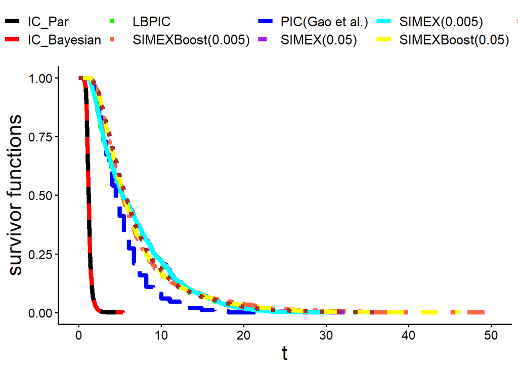